# Day 3!

## Dad Joke

- What did the French man say when he went down the slide?
- Yeeesss!

## Housekeeping

- Ideas for projects due today
  - Feedback within the next few days
- Pep talk :)
  - It’s OK to be lost
  - The class is front-loaded; we will slow down

# Paper discussion

## Analyzing large datasets is different

- Often trace data is complete*
  - Doesn’t suffer from sampling bias
  - But lots of other biases:
    - Sampled population != population of interest
    - Reliant on systems / APIs produced by others
    - Bugs in code
    - Construct validity

## Network analysis

- Turn relationships into networks
- Visual representations can be confusing

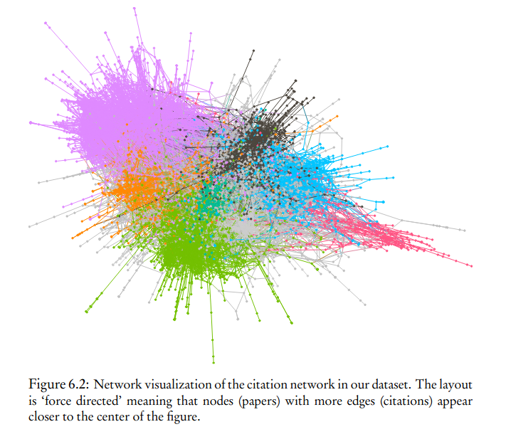

- Useful when relationships are important part of understanding a process

## Text analysis

- Lots of different approaches
  - Dictionary
  - Sentiment analysis

## Topic modeling

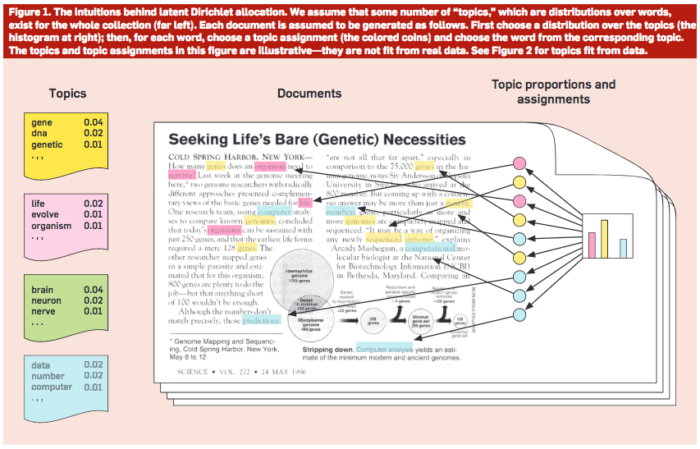

- Goal is to find a set of *k* topics where each topic is made up of a combination of terms and each document is made up of a combination of topics.
- Requires a lot of interpretation
- Computational grounded theory (Nelson, 2017) is one attempt to get “best of both worlds”

## Prediction vs inference

- Differences in focus
  - Good at predicting outcomes or understanding the process that leads to outcomes
- Prediction approaches
  - Training data and test data
  - Cross-validation and overfitting
  - Cares less about interpretability of the model or connection to theory
- Some of these can (and should!) be used by social scientists.

## Reproducibility

- Code and data can be shared really easily
- Replicate this paper?

## Concepts I want to discuss

- Importing
- Comments in code
- Functions

```python
def exclaim(s):
  # Changes a normal string into an exclamation!
  s = s.upper()
  return s + '!!'

exclaim("Hello, everyone")
```

```
## 'HELLO, EVERYONE!!'
```

## Concepts I want to discuss

- Debugging
  - print()
  - intermediate outputs
  - KISS
    - Simple functions
    - Understandable variable names

## Other concepts that are confusing?